# ProjectFoodHub_ogechi

```python
import numpy as np
import pandas as pd

# Import libraries for data visualization
import matplotlib.pyplot as plt
import seaborn as sns
from google.colab import drive
drive.mount('/content/drive')


# Read the data
df = pd.read_csv('drive/MyDrive/GreatLearningProjects/ProjectsFoodHub/foodhub_order.csv')
# Returns the first 5 rows
df.head()
```

|  | order_id | customer_id | restaurant_name | cuisine_type | cost_of_the_order | day_of_the_week | rating | food_preparation_time | delivery_time |
| --- | --- | --- | --- | --- | --- | --- | --- | --- | --- |
| 0 | 1477147 | 337525 | Hangawi | Korean | 30.75 | Weekend | Not given | 25 | 20 |
| 1 | 1477685 | 358141 | Blue Ribbon Sushi Izakaya | Japanese | 12.08 | Weekend | Not given | 25 | 23 |
| 2 | 1477070 | 66393 | Cafe Habana | Mexican | 12.23 | Weekday | 5 | 23 | 28 |
| 3 | 1477334 | 106968 | Blue Ribbon Fried Chicken | American | 29.20 | Weekend | 3 | 25 | 15 |
| 4 | 1478249 | 76942 | Dirty Bird to Go | American | 11.59 | Weekday | 4 | 25 | 24 |

```python
#Question 1: How many rows and columns are present in the data?
#Check shape of dataframe
df.shape
```

```
(1898, 9)
```

```python
#Question 2: What are the datatypes of the different columns in the dataset?
df.info()
```

```
<class 'pandas.core.frame.DataFrame'>
RangeIndex: 1898 entries, 0 to 1897
Data columns (total 9 columns):
 #   Column                 Non-Null Count  Dtype
---  ------                 --------------  -----
 0   order_id               1898 non-null   int64
 1   customer_id            1898 non-null   int64
 2   restaurant_name        1898 non-null   object
 3   cuisine_type           1898 non-null   object
 4   cost_of_the_order      1898 non-null   float64
 5   day_of_the_week        1898 non-null   object
 6   rating                 1898 non-null   object
 7   food_preparation_time  1898 non-null   int64
 8   delivery_time          1898 non-null   int64
dtypes: float64(1), int64(4), object(4)
memory usage: 133.6+ KB
```

```python
#Question 3: Are there any missing values in the data? If yes, treat them using an appropriate method.
df.isnull().sum()
print(df.isnull().sum())
```

```
order_id                 0
customer_id              0
restaurant_name          0
cuisine_type             0
cost_of_the_order        0
day_of_the_week          0
rating                   0
food_preparation_time    0
delivery_time            0
dtype: int64
```

```python
#Question 4: Check the statistical summary of the data. What is the minimum, average, and maximum time it takes for food to be prepared once an order is placed?
df.describe()
```

|  | order_id | customer_id | cost_of_the_order | food_preparation_time | delivery_time |
| --- | --- | --- | --- | --- | --- |
| count | 1.898000e+03 | 1898.000000 | 1898.000000 | 1898.000000 | 1898.000000 |
| mean | 1.477496e+06 | 171168.478398 | 16.498851 | 27.371970 | 24.161749 |
| std | 5.480497e+02 | 113698.139743 | 7.483812 | 4.632481 | 4.972637 |
| min | 1.476547e+06 | 1311.000000 | 4.470000 | 20.000000 | 15.000000 |
| 25% | 1.477021e+06 | 77787.750000 | 12.080000 | 23.000000 | 20.000000 |
| 50% | 1.477496e+06 | 128600.000000 | 14.140000 | 27.000000 | 25.000000 |
| 75% | 1.477970e+06 | 270525.000000 | 22.297500 | 31.000000 | 28.000000 |
| max | 1.478444e+06 | 405334.000000 | 35.410000 | 35.000000 | 33.000000 |

```python
#Question 5: How many orders are not rated?
df['rating'].value_counts()
```

```
Not given    736
5            588
4            386
3            188
Name: rating, dtype: int64
```

```python
#Question 6: Explore all the variables and provide observations on their distributions. (Generally, histograms, boxplots, countplots, etc. are used for univariate exploration)
# check unique order ID
df['order_id'].nunique()
```

```
1898
```

```python
#Question 6 Continued:
# check unique customer ID
df['customer_id'].nunique()   ## Complete the code to find out number of unique Customer ID
```

```
1200
```

```python
#Question 6 Continued:
# Check unique cuisine type
df['cuisine_type'].nunique() ## Complete the code to find out  number of  unique cuisine type
```

```
14
```

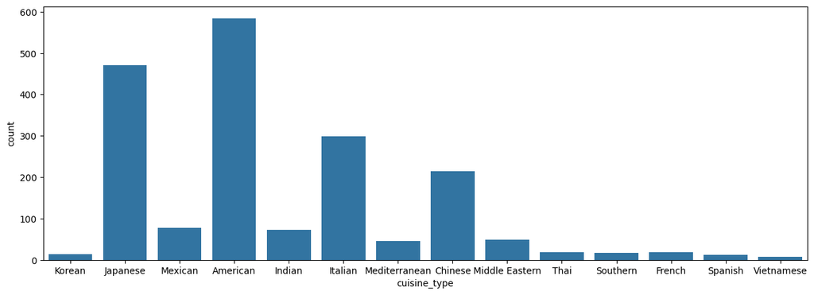

```python
#Question 6 Continued:
plt.figure(figsize = (15,5))
sns.countplot(data = df, x = 'cuisine_type') ## Create a countplot for cuisine type.
```

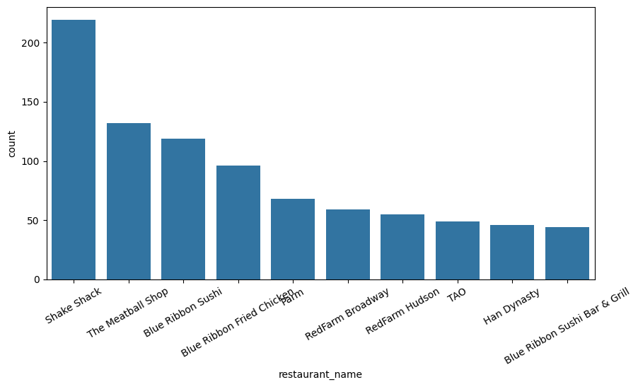

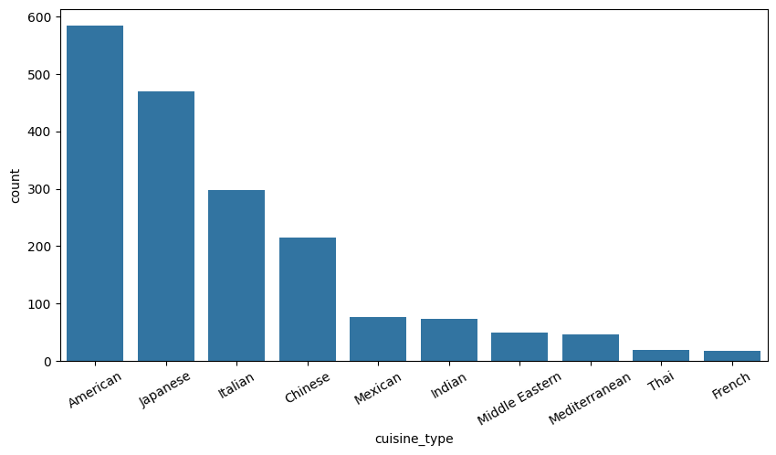

```python
#Question 6 Continued:
#categorical data with huge number of categories
columns = ['restaurant_name', 'cuisine_type']
for col in columns:
    top_10 = df[col].value_counts().head(10).index.tolist()
    plt.figure(figsize=(10, 5))
    sns.countplot(x=col, data=df, order=top_10)
    plt.xticks(rotation=30)
    plt.show()
```

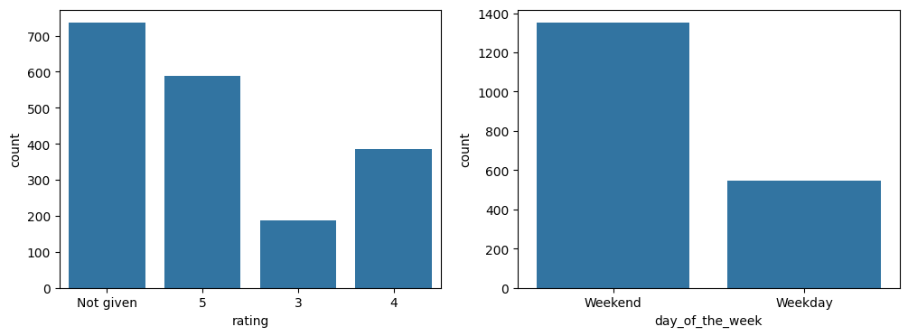

```python
#Question 6 Continued:
# categorical data with a small number of categories
fig, axes = plt.subplots(nrows=1, ncols=2, figsize=(12, 4))

sns.countplot(x='rating', data=df, ax=axes[0])
sns.countplot(x='day_of_the_week', data=df, ax=axes[1])
plt.show()
```

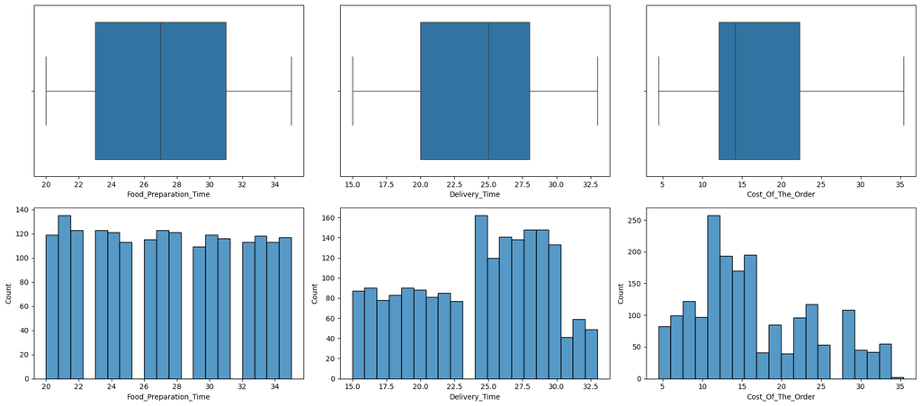

```python
#Question 6 Continued:
#numerical data
# define the list of variables
num_vars = ['food_preparation_time', 'delivery_time', 'cost_of_the_order']


fig, axes = plt.subplots(nrows=2, ncols=3, figsize=(18, 8))


for i, var in enumerate(num_vars):
    sns.boxplot(x=var, data=df, ax=axes[0, i])
    axes[0, i].set_xlabel(var.title())

    sns.histplot(x=var, data=df, bins=20, ax=axes[1, i])
    axes[1, i].set_xlabel(var.title())

plt.tight_layout()
plt.show()
```

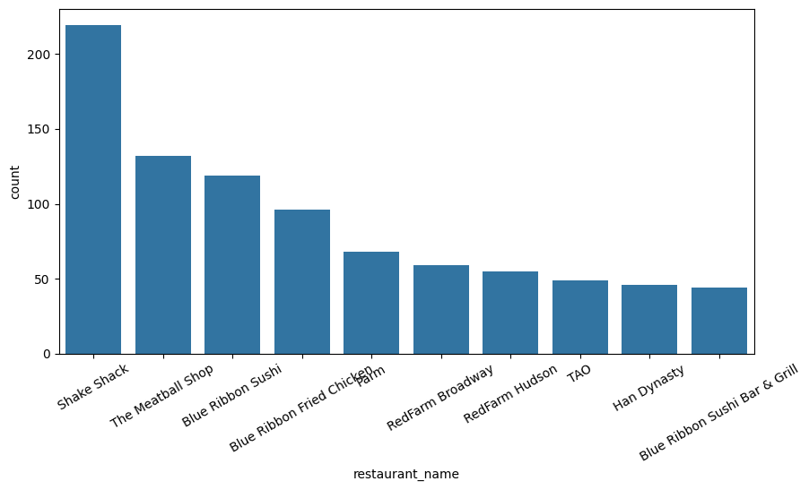

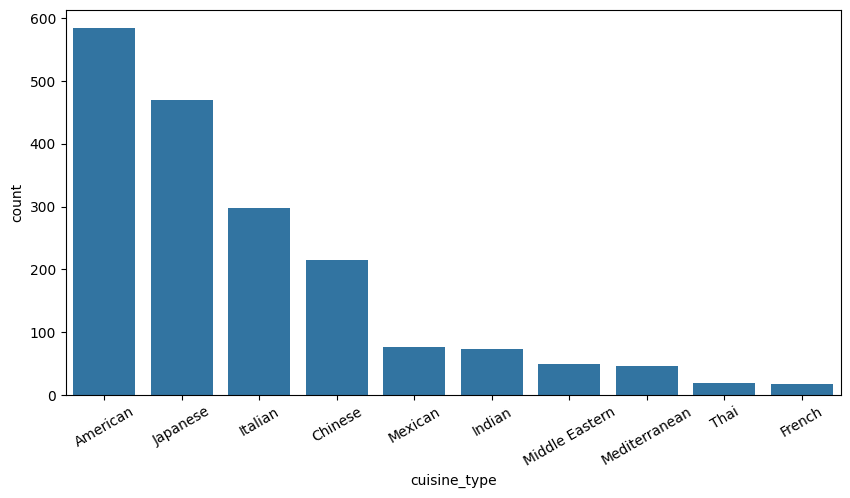

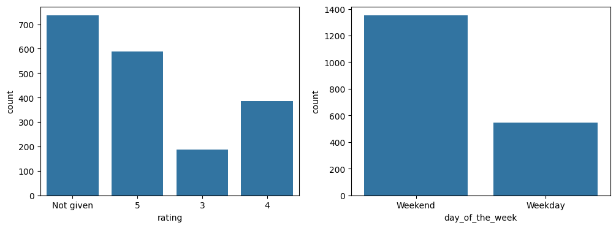

```python
# categorical data with huge number of categories
columns = ['restaurant_name', 'cuisine_type']
for col in columns:
    top_10 = df[col].value_counts().head(10).index.tolist()
    plt.figure(figsize=(10, 5))
    sns.countplot(x=col, data=df, order=top_10)
    plt.xticks(rotation=30)
    plt.show()

# categorical data with a small number of categories
fig, axes = plt.subplots(nrows=1, ncols=2, figsize=(12, 4))

sns.countplot(x='rating', data=df, ax=axes[0])
sns.countplot(x='day_of_the_week', data=df, ax=axes[1])
plt.show()
```

```python
#Question 7: Which are the top 5 restaurants in terms of the number of orders received?
# Get top 5 restaurants with highest number of orders
df['restaurant_name'].value_counts().head(5)
```

```
Shake Shack                  219
The Meatball Shop            132
Blue Ribbon Sushi            119
Blue Ribbon Fried Chicken     96
Parm                          68
Name: restaurant_name, dtype: int64
```

```python
#Question 8: Which is the most popular cuisine on weekends?
# Get most popular cuisine on weekends
df[df['day_of_the_week'] == 'Weekend']['cuisine_type'].value_counts().head(5)
```

```
American    415
Japanese    335
Italian     207
Chinese     163
Mexican      53
Name: cuisine_type, dtype: int64
```

```python
#Question 9: What percentage of the orders cost more than 20 dollars?
# Get orders that cost above 20 dollars
percent = df['cost_of_the_order'].gt(20).mean() * 100
print('Percentage of orders that cost more than $20: {:.2f}%'.format(percent))
```

```
Percentage of orders that cost more than $20: 29.24%
```

```python
#Question 10: What is the mean order delivery time?

# Get the mean delivery time
mean_delivery_time = df['delivery_time'].mean()
print(f"Mean order delivery time: {mean_delivery_time:.2f}")
```

```
Mean order delivery time: 24.16
```

```python
#Question 11: The company has decided to give 20% discount vouchers to the top 3 most frequent customers.
#Find the IDs of these customers and the number of orders they placed

# Get the counts of  each customer_id
df['customer_id'].value_counts().head(5)
```

```
52832     13
47440     10
83287      9
250494     8
259341     7
Name: customer_id, dtype: int64
```

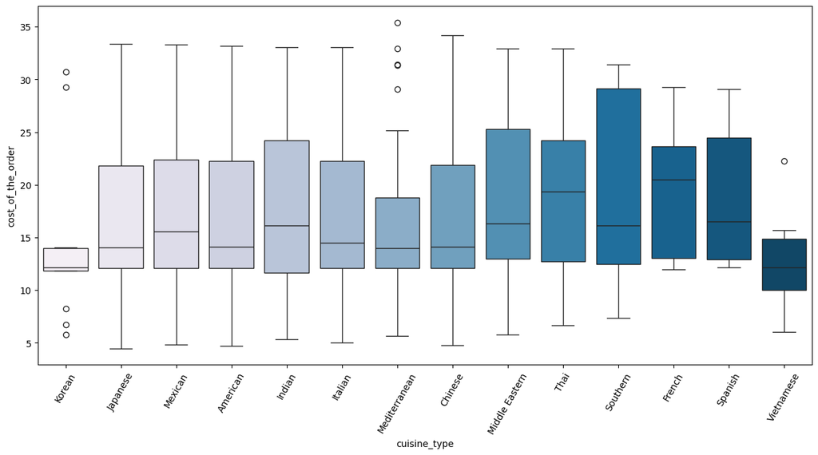

```python
#Question 12: Perform a multivariate analysis to explore relationships between the important variables in the dataset.
# It is a good idea to explore relationships between numerical variables as well as relationships
#between numerical and categorical variables

# Relationship between cost of the order and cuisine type
plt.figure(figsize=(15,7))
sns.boxplot(x = "cuisine_type", y = "cost_of_the_order", data = df, palette = 'PuBu')
plt.xticks(rotation = 60)
plt.show()
```

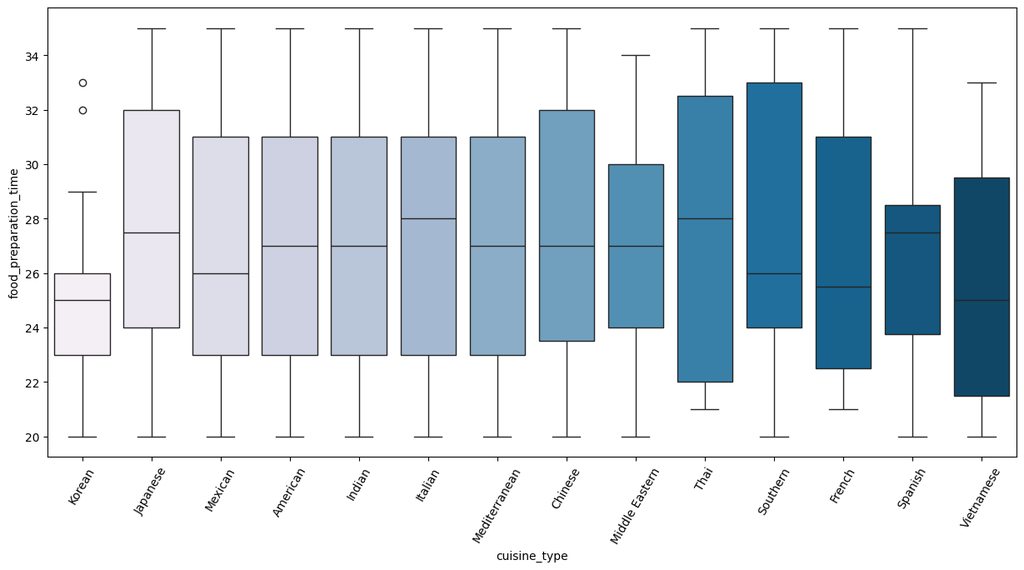

```python
#Question 12 Continued:

# Relationship between food preparation time and cuisine type
plt.figure(figsize=(15,7))
sns.boxplot(x = "cuisine_type", y = "food_preparation_time", data = df, palette ='PuBu')  ## Complete the code to visualize the relationship between food preparation time and cuisine type using boxplot
plt.xticks(rotation = 60)
plt.show()
```

#### Day of the Week vs Delivery time

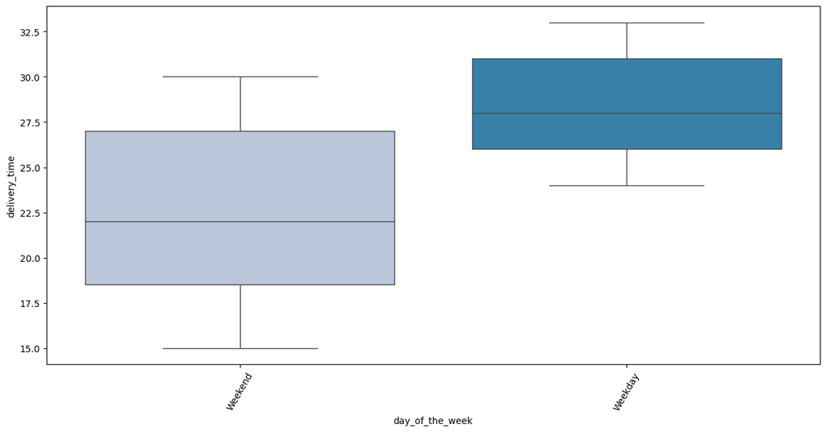

```python
# Relationship between day of the week and delivery time
plt.figure(figsize=(15,7))
sns.boxplot(x = "day_of_the_week", y = "delivery_time", data = df, palette = 'PuBu')
plt.xticks(rotation = 60)
plt.show()
## Complete the code to visualize the relationship between day of the week and delivery time using boxplot
```

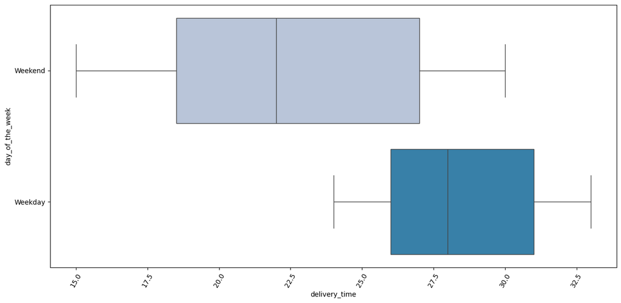

```python
# Relationship between day of the week and delivery time
plt.figure(figsize=(15,7))
sns.boxplot(x = "delivery_time", y = "day_of_the_week", data = df, palette = 'PuBu')
plt.xticks(rotation = 60)
plt.show()
## Complete the code to visualize the relationship between day of the week and delivery time using boxplot
```

#### Run the below code and write your observations on the revenue generated by the restaurants

```python
df.groupby(['restaurant_name'])['cost_of_the_order'].sum().sort_values(ascending = False).head(14)
```

```
restaurant_name
Shake Shack                      3579.53
The Meatball Shop                2145.21
Blue Ribbon Sushi                1903.95
Blue Ribbon Fried Chicken        1662.29
Parm                             1112.76
RedFarm Broadway                  965.13
RedFarm Hudson                    921.21
TAO                               834.50
Han Dynasty                       755.29
Blue Ribbon Sushi Bar & Grill     666.62
Rubirosa                          660.45
Sushi of Gari 46                  640.87
Nobu Next Door                    623.67
Five Guys Burgers and Fries       506.47
Name: cost_of_the_order, dtype: float64
```

OBSERVATIONS:

•Shake Shack is the restaurant with the highest number of orders generating the highest revenue of $3579.53.

•The 2nd and the 3rd highest revenue restaurants are The Meatball Shop & Blue Ribbon Sushi

•The 4th and 5th are Blue Ribbon Fried Chicken and Parm

•Overall we can see the restaurant with the most orders are generating good revenue

•14 restaurants are generating more than 500 dollars revenue

#### Rating vs Delivery time

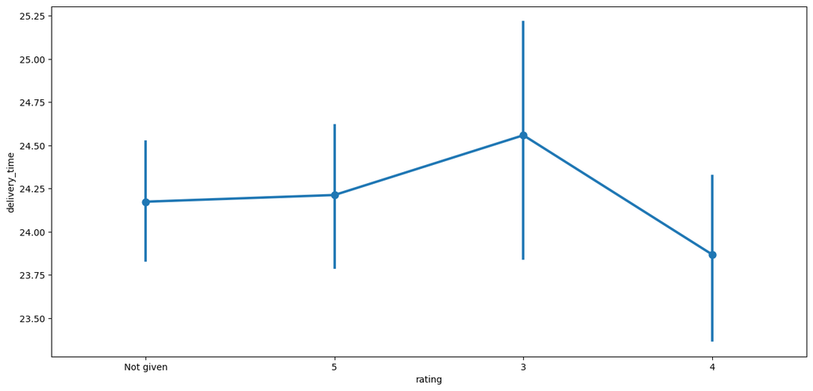

```python
# Relationship between rating and delivery time
plt.figure(figsize=(15, 7))
sns.pointplot(x = 'rating', y = 'delivery_time', data = df)
plt.show()
```

OBSERVATIONS:

• Lower Rating for Delivery Times over 24 minutes

• High-cost orders have been rated more frequent than Low-cost order

• Low-cost orders have not been rated with the same frequency as high-cost orders

Rating vs Food preparation time

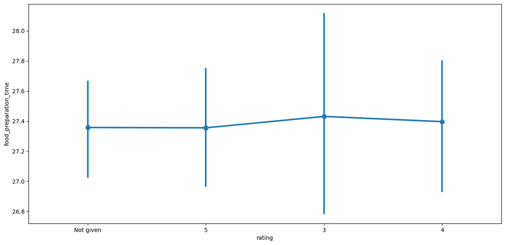

```python
# Relationship between rating and food preparation time
plt.figure(figsize=(15, 7))
sns.pointplot(x = 'rating', y = 'food_preparation_time', data = df)
plt.show()
```

OBSERVATIONS:

• There is a slight difference in model structure from above and the time range is different as this model has the time range between 26.8 and 28 minutes

• The lower food prep time has the highest rating

• The higher food prep time of approximately 27.4 minutes has lower ratings that range for 3 and 4

• This suggests an inverse relationship

Rating vs Cost of the order

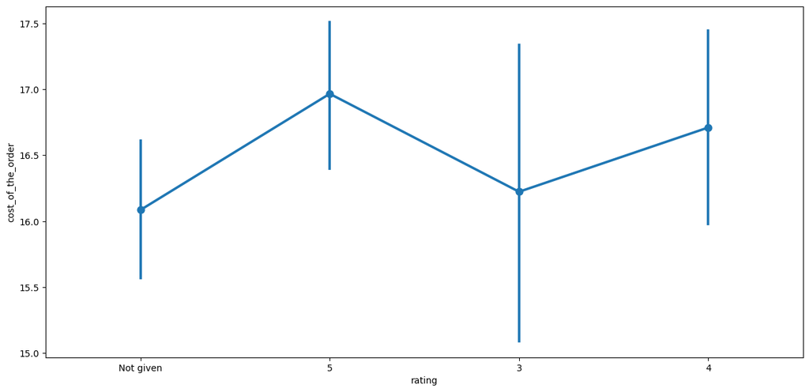

```python
# Relationship between rating and cost of the order
plt.figure(figsize=(15, 7))
sns.pointplot(x ='rating',y ='cost_of_the_order', data = df)
plt.show()
```

OBSERVATIONS:

• The highest-cost food order indicated is rated higher than the lower-cost food order

• If the food order costs $16 or less, it appears that either no rating was given or ratings are at a 3

• This suggests direct relationship between the costs of orders and the ratings

Correlation among variables

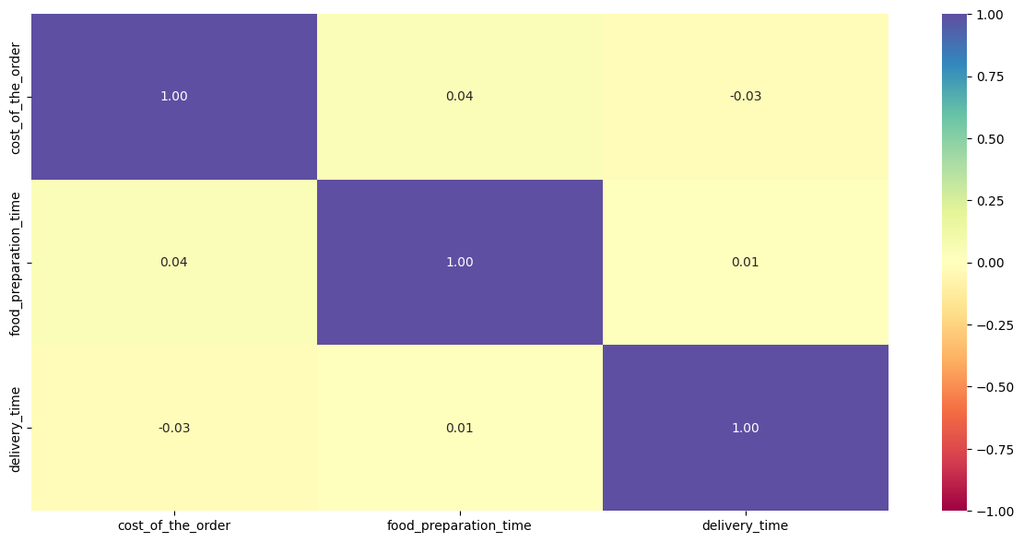

```python
# Plot the heatmap
col_list = ['cost_of_the_order', 'food_preparation_time', 'delivery_time']
plt.figure(figsize=(15, 7))
sns.heatmap(df[col_list].corr(), annot=True, vmin=-1, vmax=1, fmt=".2f", cmap="Spectral")
plt.show()
```

OBSERVATIONS:

• In the heat map chart, the cost of the order and delivery time have a less negative correlation

• Food Preparation Time and Cost of the Order has a less positive correlation

• Food Preparation Time and Delivery Time has a less positive correlation

• There is not a strong correlation among the variables: Cost of the Order, Delivery Time and Food Preparation Time

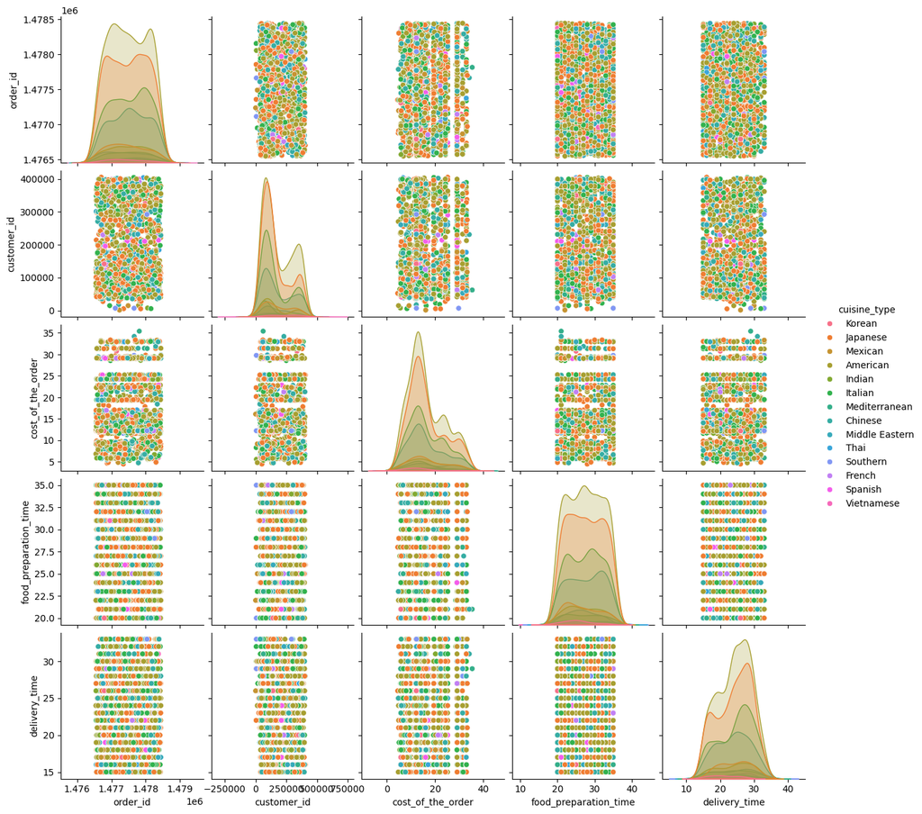

```python
sns.pairplot(df, hue="cuisine_type")
```

Question 13: The company wants to provide a promotional offer in the advertisement of the restaurants. The condition to get the offer is that the restaurants must have a rating count of more than 50 and the average rating should be greater than 4. Find the restaurants fulfilling the criteria to get the promotional offer.

```python
# Filter the rated restaurants
df_rated = df[df['rating'] != 'Not given'].copy()

# Convert rating column from object to integer
df_rated['rating'] = df_rated['rating'].astype('int')

# Create a dataframe that contains the restaurant names with their rating counts
df_rating_count = df_rated.groupby(['restaurant_name'])['rating'].count().sort_values(ascending = False).reset_index()
df_rating_count.head()
```

|  | restaurant_name | rating |
| --- | --- | --- |
| 0 | Shake Shack | 133 |
| 1 | The Meatball Shop | 84 |
| 2 | Blue Ribbon Sushi | 73 |
| 3 | Blue Ribbon Fried Chicken | 64 |
| 4 | RedFarm Broadway | 41 |

```python
# Remove rows with "Not given" ratings
df_clean = df[df['rating'] != 'Not given']

# Group by restaurant and calculate rating count and average rating
rating_stats = df_clean.groupby('restaurant_name')['rating'].agg(['count', 'mean'])

# Filter restaurants with rating count > 50 and average rating > 4
promo_restaurants = rating_stats[(rating_stats['count'] > 50) & (rating_stats['mean'] > 4)]

# Print the list of restaurants fulfilling the criteria
print(promo_restaurants.index.tolist())
```

```
['Blue Ribbon Fried Chicken', 'Blue Ribbon Sushi', 'Shake Shack', 'The Meatball Shop']
```

OBSERVATIONS: Blue Ribbon Fried Chicken, Blue Ribbon Sushi, Shake Shack, The Meatball Shop restaurants have ratings count greater than 50 and the average rating is greater 4.

Question 14: The company charges the restaurant 25% on the orders having cost greater than 20 dollars and 15% on the orders having cost greater than 5 dollars. Find the net revenue generated by the company across all orders

```python
#function to determine the revenue
def compute_rev(x):
    if x > 20:
        return x*0.25
    elif x > 5:
        return x*0.15
    else:
        return x*0

df['Revenue'] = df['cost_of_the_order'].apply(compute_rev) ## Write the apprpriate column name to compute the revenue
df.head()
```

|  | order_id | customer_id | restaurant_name | cuisine_type | cost_of_the_order | day_of_the_week | rating | food_preparation_time | delivery_time | Revenue |
| --- | --- | --- | --- | --- | --- | --- | --- | --- | --- | --- |
| 0 | 1477147 | 337525 | Hangawi | Korean | 30.75 | Weekend | Not given | 25 | 20 | 7.6875 |
| 1 | 1477685 | 358141 | Blue Ribbon Sushi Izakaya | Japanese | 12.08 | Weekend | Not given | 25 | 23 | 1.8120 |
| 2 | 1477070 | 66393 | Cafe Habana | Mexican | 12.23 | Weekday | 5 | 23 | 28 | 1.8345 |
| 3 | 1477334 | 106968 | Blue Ribbon Fried Chicken | American | 29.20 | Weekend | 3 | 25 | 15 | 7.3000 |
| 4 | 1478249 | 76942 | Dirty Bird to Go | American | 11.59 | Weekday | 4 | 25 | 24 | 1.7385 |

```python
# get the total revenue and print it
total_rev = df['Revenue'].sum() # Write the appropriate function to get the total revenue
print('The net revenue is around', round(total_rev, 2), 'dollars')
```

```
The net revenue is around 6166.3 dollars
```

Question 15: The company wants to analyze the total time required to deliver the food. What percentage of orders take more than 60 minutes to get delivered from the time the order is placed? (The food has to be prepared and then delivered)

```python
# Calculate total delivery time and add a new column to the dataframe df to store the total delivery time
df['total_time'] = df['food_preparation_time'] + df['delivery_time']
```

```python
# find the percentage of orders that have more than 60 minutes of total delivery time
pa=len(df[df.total_time > 60].value_counts())/len(df)*100
print('percentage of the orders taking more than 60 minutes in total: ', round(pa,2), '%')
```

```
percentage of the orders taking more than 60 minutes in total:  10.54 %
```

Question 16: The company wants to analyze the delivery time of the orders on weekdays and weekends. How does the mean delivery time vary during weekdays and weekends?

```python
# Get the mean delivery time on weekdays and print it
print('The mean delivery time on weekdays is around',
      round(df[df['day_of_the_week'] == 'Weekday']['delivery_time'].mean()),
     'minutes')
```

```
The mean delivery time on weekdays is around 28 minutes
```

```python
## Write the code below to get the mean delivery time on weekends and print it
print('The mean delivery time on weekend is around',
round(df[df['day_of_the_week'] == 'Weekend']['delivery_time'].mean()),
'minutes')
```

```
The mean delivery time on weekend is around 22 minutes
```

Question 17: What are your conclusions from the analysis? What recommendations would you like to share to help improve the business? (You can use cuisine type and feedback ratings to drive your business recommendations.)

CONCLUSIONS:

• About 80% of the orders are for American, Japanese, Italian and Chinese cuisines. Thus, it seems that these cuisines are quite popular amongst Food Hub customers.

• Shake Shack is the most popular restaurant that has received the highest number of orders.

• The most Expensive cuisine is French Cuisine.

• After customers placed orders, the Food Preparation Time is between 20 to 36 minutes approximately.

• The minimum Cost of the Order is 4.47 dollars and the maximum is 35.41 dollars.

• Most of the orders are placed during the weekends.

• The volume of orders increase on the weekends compared to the weekdays.

• Delivery time over the weekends is less compared to the weekdays (which could be due to reduced traffic volume on the weekends).

• Around 11% of the total orders have more than 60 minutes of total delivery time.

• Around 39% of the orders have not been rated.

• Weekend Delivery Time is less than Weekday Delivery Time.

• A total of 736 out 0f 1,898 orders were not rated.

• There is no linear relationship between the variable columns.

RECOMMENDATIONS:

• FoodHub should integrate with restaurants serving American, Japanese, Italian and Chinese cuisines since these cuisines are very popular amongst FoodHub customers.

• FoodHub should provide promotional offers to top-rated popular restaurants like Shake Shack that serve a majority of their customers and account for the largest amount of their orders.

• As the order volume is high during the weekends, more delivery staff should be employed during the weekends to ensure timely delivery of the order.

• Weekend promotional offers should be given to the customers to increase the food orders during weekends. Providings these offerings to their customers may increase revenue.

• Because Customer Rating is a very important factor to gauge customer satisfaction and to market and gain new customers, FoodHub should investigate the reason behind the low count of ratings.

• FoodHub could redesign the rating page in their app to be more interactive to better encourage and entice customers to rate food orders.

• FoodHub should run Weekday Specials or bundle higher priced items during the slower days of the week say Mondays and Tuesdays to increase weekday revenue and to encourage feedback for ratings.

• Since approximately 11% of the total orders have more than 60 minutes of total delivery time, FoodHub should try to reduce this to create a better customer experience.

• FoodHub should incentivize delivery staff being on time, in otherwords, FoodHub can provide rewards to delivery dtaff who deliver food orders on time.

• FoodHub should conduct analysis and investigate the weekday delivery time efficiency because people are busier during the week with their jobs and commitments and are more impatient. Reducing weekday delivery times will increase their ratings and will help to build their customer base.

• FoodHub should model delivery routes for weekdays and weekends to optimize delivery time and to drive sales.

• FoodHub should conduct surveys to understand what drives weekend sales to be higher than weekday. Coming directly from the customer may help FoodHub provide better service and create a better relationship with their customers. If the survey is incentivized, say a customer will get half off a high menu item, FoodHub will increase their data collection of feedback and ratings which will allow them to be better decision makers and may allow them to do some trend analysis so they better know how to market to their customers.

• FoodHub should research and investigate how to increase efficiency during optimal time frames for weekday deliveries.

• FoodHub should analyze data to determine and confirm peak weekday order times and based on peak time ranges, add more delivery drivers accordingly.